# NYC Citi Bikes Report

2023-05-03

[output not shown]

# Introduction

This report analyses the `nyc_bikes` data set. This is sample of bike trips which provides information on rider demographics, along with when and where they used the bike. There is a sample size of 4,268 trips.

When analysing this data, some ethical considerations were adhered to, such as:

1. Privacy: The data set contains personal information such as birth year and gender. It’s important to ensure that the data is anonymized, and that any analysis does not allow for the identification of individuals.
2. Informed consent: Riders may not be aware that their data is being collected and used. It is important to ensure that the data has been collected with the informed consent of the individuals.
3. Data quality: It is important to verify that the data is accurate and reliable before drawing any conclusions from it. It’s essential to check the data for any outliers or errors that may affect the accuracy of the analysis.

A key component of the Citi Bike business model is the subscription scheme where users pay an annual fee for unlimited access of the bikes.

This report will look to answer the following question which will boost one of the key performance indicators (KPIs) which is subscribers: “How do we boost subscriber growth?”

## 1: Breakdown of User Demographics

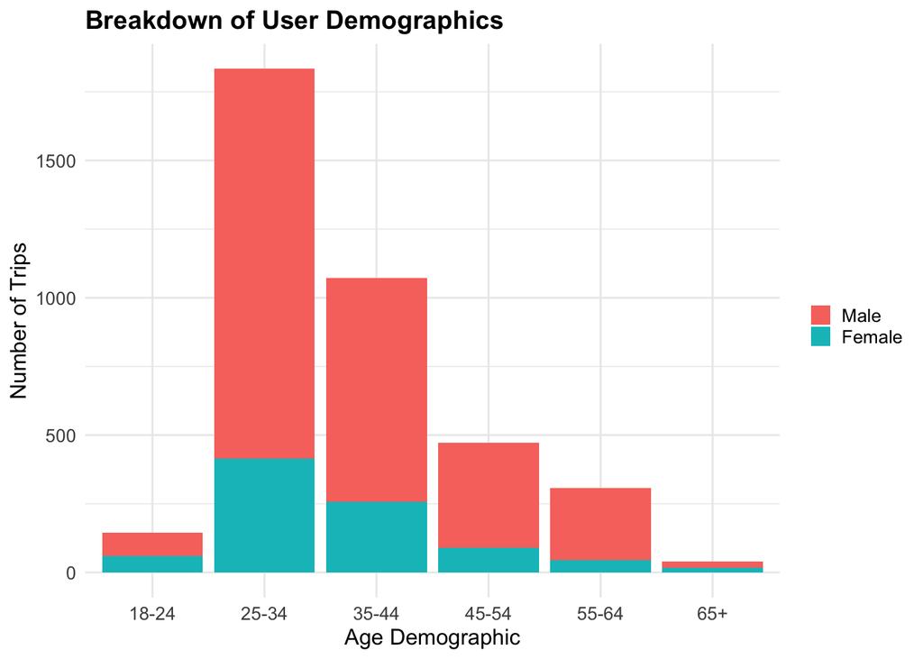

This graph breaks down the user demographics of who is making use of the service.

The data highlights that the majority of users are male, with the main age demographic being the 25-34 age range. Potential areas for growth are:

- Increasing the amount of female subscribers
- Increasing the about of subscribers in the 18-24 & 65+ demographic.

Recommendations to increase subscriber growth KPI in these areas will be discussed later on in the report.

## 2: Subscriber Useage in 2018

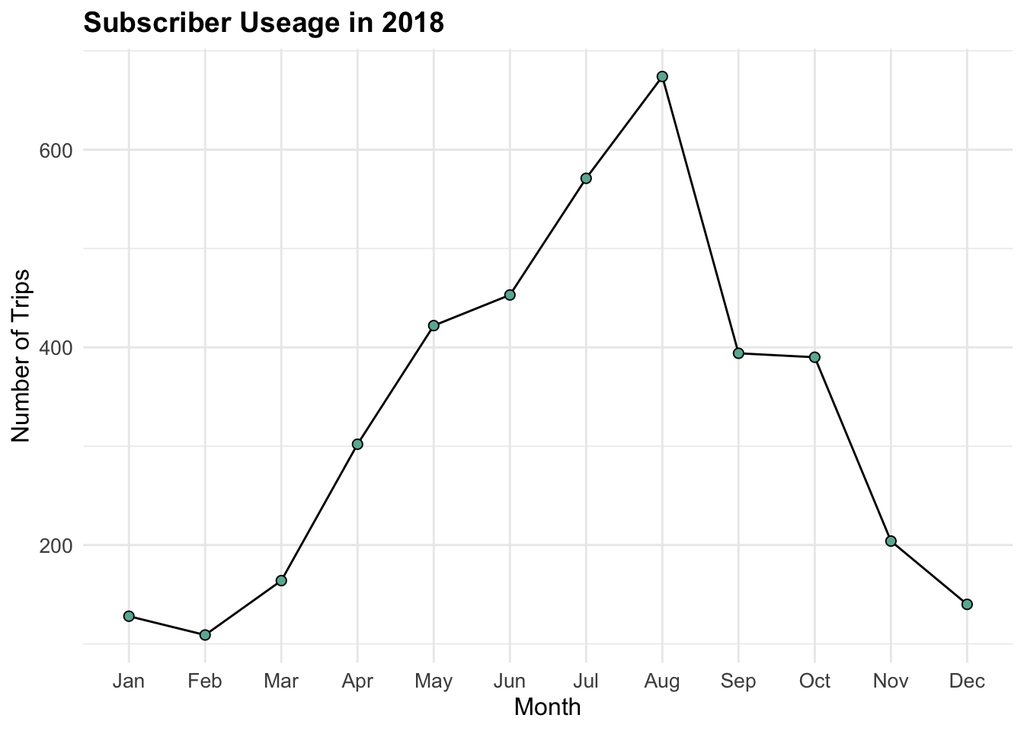

There is an increase in the amount of trips taken by subscribers in the summer months reaching a peak in August. This suggests users are more likely to use the service in warmer weather.

Further in the report, potential strategies to increase engagement in the winter month will be reviewed.

## 3. Peak Times

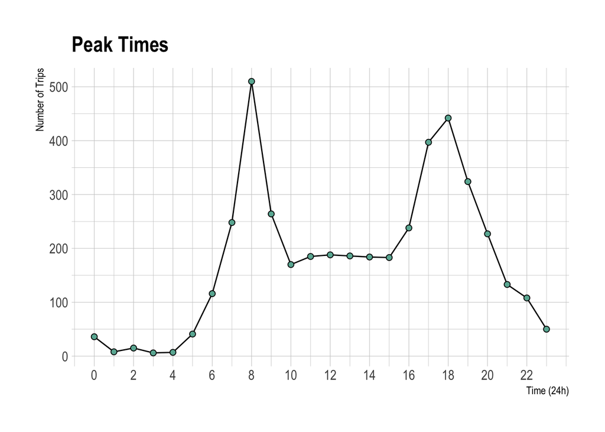

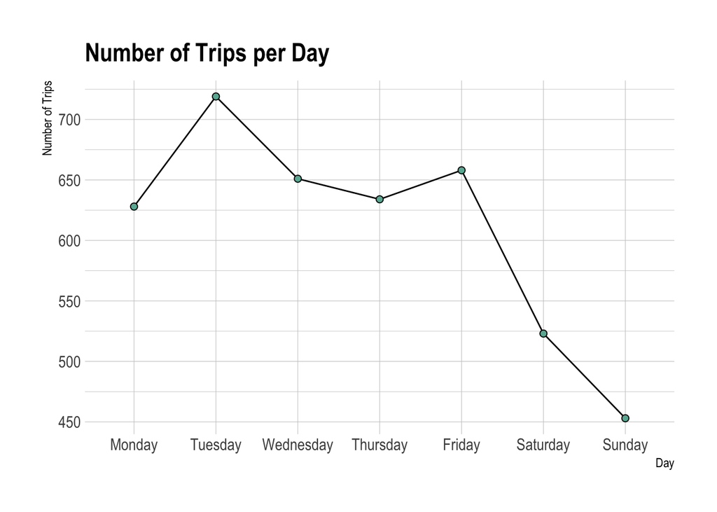

The previous graphs suggests that subscribers are using the service to commute to and from work. The graphs also show that there is a sharp decrease in usage over the weekend.

Therefore, areas of improvement from the data could be to capitalise on the commuter cohort, and to increase weekend use.

The aforementioned improvements will be further discussed in the conclusion section of the report.

## Location Popularity

[interactive chart not shown]

The majority of stations are located within Jersey City, with the borough of Hoboken containing lowest amount stations; this is despite it being surrounded by areas with high concentration levels of Citi Bike stations.

## Conclusions

Based on an analysis of the Citi Bike data set, the following distinctions were analysed:

- The vast majority of subscribers are male
- The main age demographic of subscribers are 25-34, with those aged 65+ and 18-24 using the service the least
- The summer months are busier than the winter months, declining from August onwards
- Subscribers are most likely to use the service on weekdays, which suggests a vast proportion of subscribers are using the service for commuting
- Most of the stations are located in Jersey City, with a lack of stations within the nearby Hoboken district

From this analysis, and the aforementioned distinctions, the following recommendations are suggested in order to drive the KPI of subscribers:

1. A targeted marketing campaign for females, in order to boost female subscriber growth. Citi Bikes should also lean in to the already offered community events, and push out more marketing to attract a younger cohort of subscribers. Community events which have a focus on a female audience, and showcasing female rider safety, should feature more prominently.
2. The subscriber system should have a young persons discount to drive sales in the 18-24 age bracket and a 65+ discount.
3. In order to boost Winter subscription use, a specific seasonal campaign should be implemented. For example, if a customer were to sign up for a year in November, they would receive a discount.
4. Citi Bikes should lean in to the commuter market, and offer a commuter pass to encourage more commuters to cycle to work. Marketing campaigns could draw on the health, environment, and wellness benefits, and the pass would offer riders two rides a day at a discounted price compared to the standard subscription.
5. Hoboken is a high population area, and is surrounded by popular districts Citi Bikes should implement more stations within this area to drive user growth and to allow the population the opportunity to use Citi Bikes.